# dplyr, tidyr : Coder (presque) comme on parle

24 novembre 2014

## Une nouvelle génération de packages

AKA le ["Hadleyverse"](https://github.com/hadley/)

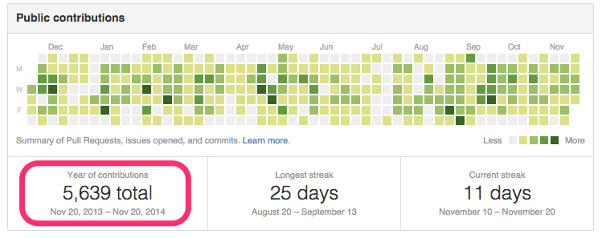

## Une nouvelle génération de packages

`dplyr`, `tidyr`, `ggplot2` bien sûr, `ggvis`, `httr`, `rvest`, etc.

## Des packages centrés sur le point fort de `R`

`dplyr` et `tidyr` sont des réimplémentations de `plyr` et `reshape` spécialisés sur les dataframes.

## Une syntaxe renouvelée

Deux principes :

- l'usage de verbes - c'est-à-dire une fonction qui prend un data.frame comme premier argument (`group_by`, `summarise`, `select`, `filter`, `arrange`, `spread`, `gather`)
- l'usage du pipe `%>%` (qui se lit "then" et vient du package `magrittr`)

```r
library(nycflights13)
library(dplyr)
flights
```

```
## Source: local data frame [336,776 x 16]
##
##    year month day dep_time dep_delay arr_time arr_delay carrier tailnum
## 1  2013     1   1      517         2      830        11      UA  N14228
## 2  2013     1   1      533         4      850        20      UA  N24211
## 3  2013     1   1      542         2      923        33      AA  N619AA
## 4  2013     1   1      544        -1     1004       -18      B6  N804JB
## 5  2013     1   1      554        -6      812       -25      DL  N668DN
## 6  2013     1   1      554        -4      740        12      UA  N39463
## 7  2013     1   1      555        -5      913        19      B6  N516JB
## 8  2013     1   1      557        -3      709       -14      EV  N829AS
## 9  2013     1   1      557        -3      838        -8      B6  N593JB
## 10 2013     1   1      558        -2      753         8      AA  N3ALAA
## ..  ...   ... ...      ...       ...      ...       ...     ...     ...
## Variables not shown: flight (int), origin (chr), dest (chr), air_time
##   (dbl), distance (dbl), hour (dbl), minute (dbl)
```

## Permet une lecture plus aisée du code

```r
flights %>%
  filter(carrier %in% "UA")
```

```
## Source: local data frame [58,665 x 16]
##
##    year month day dep_time dep_delay arr_time arr_delay carrier tailnum
## 1  2013     1   1      517         2      830        11      UA  N14228
## 2  2013     1   1      533         4      850        20      UA  N24211
## 3  2013     1   1      554        -4      740        12      UA  N39463
## 4  2013     1   1      558        -2      924         7      UA  N29129
## 5  2013     1   1      558        -2      923       -14      UA  N53441
## 6  2013     1   1      559        -1      854        -8      UA  N76515
## 7  2013     1   1      607         0      858       -17      UA  N53442
## 8  2013     1   1      611        11      945        14      UA  N532UA
## 9  2013     1   1      623        -4      933         1      UA  N459UA
## 10 2013     1   1      628        -2     1016        29      UA  N33289
## ..  ...   ... ...      ...       ...      ...       ...     ...     ...
## Variables not shown: flight (int), origin (chr), dest (chr), air_time
##   (dbl), distance (dbl), hour (dbl), minute (dbl)
```

## Permet une lecture plus aisée du code

```r
flights %>%
  filter(carrier %in% "UA") %>%
  select(year, month, day, carrier, origin, dest)
```

```
## Source: local data frame [58,665 x 6]
##
##    year month day carrier origin dest
## 1  2013     1   1      UA    EWR  IAH
## 2  2013     1   1      UA    LGA  IAH
## 3  2013     1   1      UA    EWR  ORD
## 4  2013     1   1      UA    JFK  LAX
## 5  2013     1   1      UA    EWR  SFO
## 6  2013     1   1      UA    EWR  LAS
## 7  2013     1   1      UA    EWR  MIA
## 8  2013     1   1      UA    JFK  SFO
## 9  2013     1   1      UA    LGA  IAH
## 10 2013     1   1      UA    EWR  LAX
## ..  ...   ... ...     ...    ...  ...
```

## Permet une lecture plus aisée du code

```r
flights %>%
  group_by(year, month, day) %>%
  summarise(delay = mean(arr_delay, na.rm = TRUE))
```

```
## Source: local data frame [365 x 4]
## Groups: year, month
##
##    year month day      delay
## 1  2013     1   1 12.6510229
## 2  2013     1   2 12.6928879
## 3  2013     1   3  5.7333333
## 4  2013     1   4 -1.9328194
## 5  2013     1   5 -1.5258020
## 6  2013     1   6  4.2364294
## 7  2013     1   7 -4.9473118
## 8  2013     1   8 -3.2275785
## 9  2013     1   9 -0.2642777
## 10 2013     1  10 -5.8988159
## ..  ...   ... ...        ...
```

## Permet une lecture plus aisée du code

```r
flights %>%
  group_by(paste(year, month, day, sep = "-")) %>%
  summarise(delay = mean(arr_delay, na.rm = TRUE)) %>%
  arrange(desc(delay))
```

```
## Source: local data frame [365 x 2]
##
##    paste(year, month, day, sep = "-")    delay
## 1                            2013-3-8 85.86216
## 2                           2013-6-13 63.75369
## 3                           2013-7-22 62.76340
## 4                           2013-5-23 61.97090
## 5                           2013-7-10 59.62648
## 6                           2013-9-12 58.91242
## 7                            2013-7-1 58.28050
## 8                          2013-12-17 55.87186
## 9                            2013-8-8 55.48116
## 10                          2013-12-5 51.66625
## ..                                ...      ...
```

## Permet une lecture plus aisée du code

```r
flights %>%
  mutate(date = paste(year, month, day, sep = "-")) %>%
  group_by(date) %>%
  summarise(delay = mean(arr_delay, na.rm = TRUE)) %>%
  arrange(desc(delay))
```

```
## Source: local data frame [365 x 2]
##
##          date    delay
## 1    2013-3-8 85.86216
## 2   2013-6-13 63.75369
## 3   2013-7-22 62.76340
## 4   2013-5-23 61.97090
## 5   2013-7-10 59.62648
## 6   2013-9-12 58.91242
## 7    2013-7-1 58.28050
## 8  2013-12-17 55.87186
## 9    2013-8-8 55.48116
## 10  2013-12-5 51.66625
## ..        ...      ...
```

## Résumé des principaux verbes

- `group_by` : crée des groupes
- `summarise` : agrège un dataframe ou un un groupe en une ligne
- `filter` : subset en fonction de conditions logiques
- `select` : sélectionne certaines variables seulement
- `arrange` : trie le data.frame selon certaines variables
- `mutate` : crée de nouvelles variables

## Et aussi…

- `count` : nombre de lignes
- `do` : permet de faire n'importe quelle opération sur des groupes (ex : `lm`)
- sélection aisée de variables : `data %>% select(varA:varZ)` ou encore `data %>% select(-varB)`
- joins (en style SQL)
- `sample_n()` et `sample_frac`
- écrit en C++, donc *rapide*

## Les `tables` peuvent venir de sources différentes

- de `datatable`
- et SURTOUT de bases de données !

```r
my_db <- src_sqlite("my_db.sqlite3", create = T)
flights_sqlite <- copy_to(my_db, flights, temporary = TRUE, indexes = list(
  c("year", "month", "day"), "carrier", "tailnum"))

flights_sqlite %>%
  filter(origin == "JFK") %>%
  arrange(desc(distance))
```

```
## Source: sqlite 3.8.6 [my_db.sqlite3]
## From: flights [111,279 x 16]
## Filter: origin == "JFK"
## Arrange: desc(distance)
##
##    year month day dep_time dep_delay arr_time arr_delay carrier tailnum
## 1  2013     1   1      857        -3     1516       -14      HA  N380HA
## 2  2013     1   2      909         9     1525        -5      HA  N380HA
## 3  2013     1   3      914        14     1504       -26      HA  N380HA
## 4  2013     1   4      900         0     1516       -14      HA  N384HA
## 5  2013     1   5      858        -2     1519       -11      HA  N381HA
## 6  2013     1   6     1019        79     1558        28      HA  N385HA
## 7  2013     1   7     1042       102     1620        50      HA  N385HA
## 8  2013     1   8      901         1     1504       -26      HA  N389HA
## 9  2013     1   9      641      1301     1242      1272      HA  N384HA
## 10 2013     1  10      859        -1     1449       -41      HA  N388HA
## ..  ...   ... ...      ...       ...      ...       ...     ...     ...
## Variables not shown: flight (int), origin (chr), dest (chr), air_time
##   (dbl), distance (dbl), hour (dbl), minute (dbl)
```

## Oui, mais…

- on ne peut pas programmer avec `dplyr` ?
  - si : avec les fonctions spéciales du type `select_`
- il n'y a pas d'autocomplétion dans Rstudio ?
  - si : ça arrive
- Il n'y a pas de parallélisation possible ?
  - Non, pas encore, mais c'est prévu.

## `tidyr`, un complément logique de `dplyr`

`tidyr` est à `dplyr` ce que `reshape` est à `plyr`.

Deux (et deux seulement !) fonctions :

- `gather` (format large -> format long)
- `spread` (format long -> format large)

avec un système clé-valeur

```r
library(tidyr)
messy <- data.frame(
  name = c("Wilbur", "Petunia", "Gregory"),
  a = c(67, 80, 64),
  b = c(56, 90, 50)
  )

messy %>%
  gather(drug, heartrate, a:b)
```

```
##      name drug heartrate
## 1  Wilbur    a        67
## 2 Petunia    a        80
## 3 Gregory    a        64
## 4  Wilbur    b        56
## 5 Petunia    b        90
## 6 Gregory    b        50
```

## Pour conclure

`dplyr`, `tidyr` et d'autres packages permettent :

- une écriture plus fluide
- une plus grande efficacité et rapidité
- une plus grande abstraction
- d'avoir une plus belle beau et des cheveux brillants.

Alors, n'hésitez plus !